# Day 7 Introduction to Linear Models

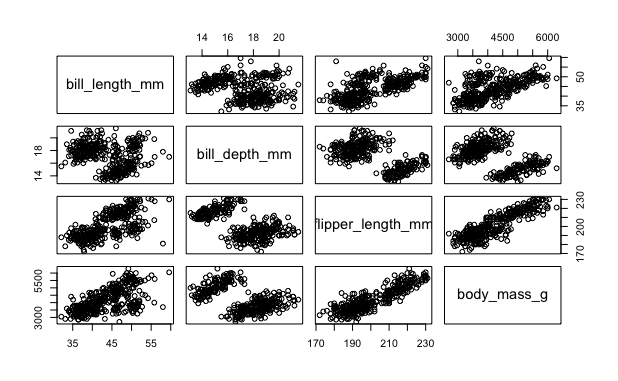

```r
library(tidyverse)
penguins = read_csv("/Users/pp16/Desktop/NTU/UCL exchange/week 1 day 5/penguins_knn.csv")
pairs(select(penguins, bill_length_mm, bill_depth_mm, flipper_length_mm, body_mass_g))
```

Flipper length seems to be most clearly related to body mass so we can build a linear model based on that.

## Compare mass and flipper length

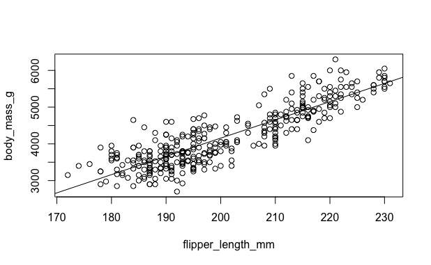

```r
mass_flipper = lm(body_mass_g~flipper_length_mm, data=penguins)
plot(body_mass_g~flipper_length_mm, data=penguins)
abline(mass_flipper)
```

- if use mutiple data, read adjusted R-squared.
- If use one data, use mutiple R-squared

```r
summary(mass_flipper)
```

```
Call:
lm(formula = body_mass_g ~ flipper_length_mm, data = penguins)

Residuals:
     Min       1Q   Median       3Q      Max
-1058.80  -259.27   -26.88   247.33  1288.69

Coefficients:
                   Estimate Std. Error t value Pr(>|t|)
(Intercept)       -5780.831    305.815  -18.90   <2e-16 ***
flipper_length_mm    49.686      1.518   32.72   <2e-16 ***
---
Signif. codes:  0 ‘***’ 0.001 ‘**’ 0.01 ‘*’ 0.05 ‘.’ 0.1 ‘ ’ 1

Residual standard error: 394.3 on 340 degrees of freedom
  (2 observations deleted due to missingness)
Multiple R-squared:  0.759, Adjusted R-squared:  0.7583
F-statistic:  1071 on 1 and 340 DF,  p-value: < 2.2e-16
```

- Resulting formula : `body_mass_g = -5780 + flipper_length_mm*49.686`
- Residual standard error can use to compare which model is better
- Std. Error can be use to calculate confidence intervals

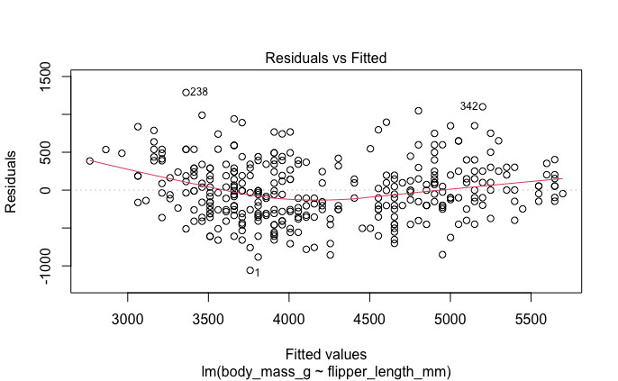

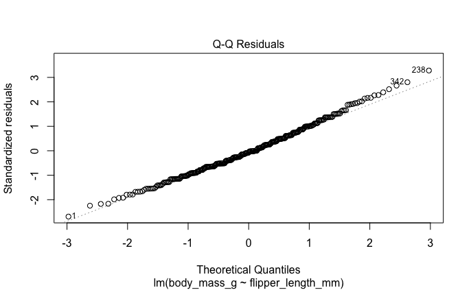

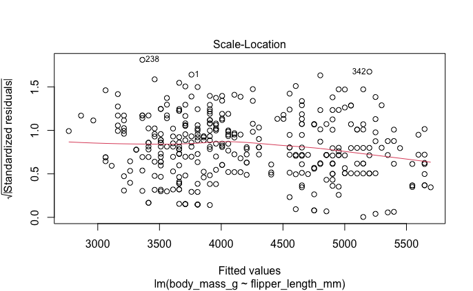

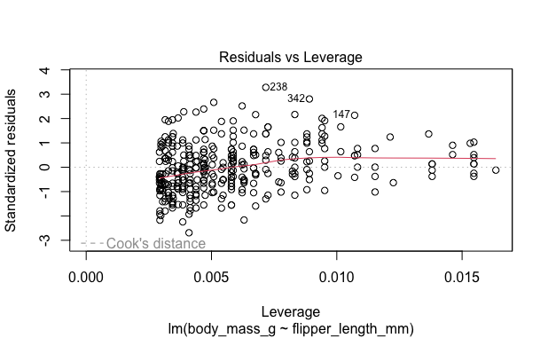

```r
plot(mass_flipper)
```

- For residuals vs fitted, ideal is 0
- QQ we want to see most of the points on the line
- if there is an outlier, on residuals vs leverage, there will be a point to show a stretch of the cook distance

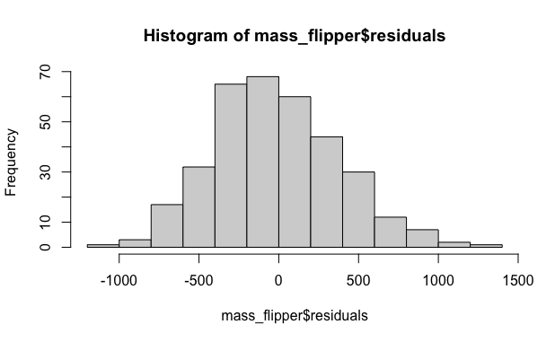

```r
hist(mass_flipper$residuals)
```

## Compare body mass and bill length

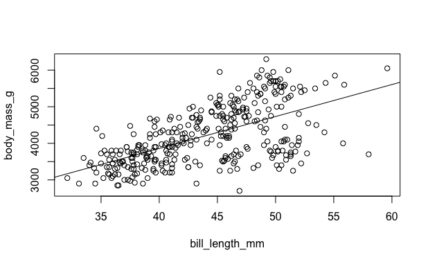

```r
mass_bill = lm(body_mass_g ~ bill_length_mm, data = penguins)
plot(body_mass_g ~ bill_length_mm, data=penguins)
abline(mass_bill)
```

```r
summary(mass_bill)
```

```
Call:
lm(formula = body_mass_g ~ bill_length_mm, data = penguins)

Residuals:
     Min       1Q   Median       3Q      Max
-1762.08  -446.98    32.59   462.31  1636.86

Coefficients:
               Estimate Std. Error t value Pr(>|t|)
(Intercept)     362.307    283.345   1.279    0.202
bill_length_mm   87.415      6.402  13.654   <2e-16 ***
---
Signif. codes:  0 ‘***’ 0.001 ‘**’ 0.01 ‘*’ 0.05 ‘.’ 0.1 ‘ ’ 1

Residual standard error: 645.4 on 340 degrees of freedom
  (2 observations deleted due to missingness)
Multiple R-squared:  0.3542,    Adjusted R-squared:  0.3523
F-statistic: 186.4 on 1 and 340 DF,  p-value: < 2.2e-16
```

## Exercise

- Load in the data file.
- Check that the data types are set up appropriately.
- Check the amount of data in the dataset, and whether there is any missing data.
- Think: What relationships might you expect to find in this dataset?
- Explore the relationships between the variables and the price.
- Identify which factors seem to be most important in determining house price.

- Determine if there are any factors that do not seem important.

Sale-date

- Investigate other relationships between the input variables.
- Once you have explored the data, try to make plots that illustrate your key findings.

can log distance to expand the values

```r
estate = estate %>%
  mutate(log_distance = log10(dist_to_transport))
```

Add in log distance to transport

Build our models

## Stepwise Model Selection

- builds up our model step-by-step
- StepAIC function from MASS

```r
#install.packages("MASS")
library(MASS)
library(tidyverse)
select <- dplyr::select
```

```r
model_step <- stepAIC(model_min,
                      direction = "forward",
                      scope = scp,
                      steps = 1)
```

```
Start:  AIC=2162.53
price_per_sqm ~ 1

               Df Sum of Sq   RSS    AIC
+ log_distance  1     41232 35229 1843.7
+ num_stores    1     24930 51531 2001.2
+ latitude      1     22820 53641 2017.8
+ longitude     1     20937 55524 2032.1
+ house_age     1      3390 73071 2145.8
+ sale_date     1       585 75876 2161.3
<none>                      76461 2162.5

Step:  AIC=1843.72
price_per_sqm ~ log_distance
```

```r
#one step at a time
#lower AIC better
```

```r
mode_stepback = stepAIC(model_max,
                     direction = "backward",
                     score=scp)
```

```
Start:  AIC=1736.86
price_per_sqm ~ (sale_date + house_age + dist_to_transport +
    num_stores + latitude + longitude + log_distance) - dist_to_transport

               Df Sum of Sq   RSS    AIC
- longitude     1      18.8 26584 1735.2
<none>                      26566 1736.9
- num_stores    1     236.8 26802 1738.5
- sale_date     1    1370.4 27936 1755.7
- house_age     1    2767.0 29333 1775.9
- latitude      1    3694.4 30260 1788.8
- log_distance  1    8431.4 34997 1849.0

Step:  AIC=1735.16
price_per_sqm ~ sale_date + house_age + num_stores + latitude +
    log_distance

               Df Sum of Sq   RSS    AIC
<none>                      26584 1735.2
- num_stores    1     233.3 26818 1736.8
- sale_date     1    1376.3 27961 1754.0
- house_age     1    2777.2 29362 1774.3
- latitude      1    3904.0 30488 1789.9
- log_distance  1   11535.1 38119 1882.4
```

## Exhaustive Search for Variable Selection

```r
#install.packages("leaps")
library(leaps)

regsubsets_out <- regsubsets( price_per_sqm ~ . - dist_to_transport,
                             data = estate,
                             nbest = 1,
                             nvmax = NULL,
                             force.in = NULL,
                             force.out = NULL,
                             method = 'exhaustive'
                            )
summary(regsubsets_out)
```

```
Subset selection object
Call: regsubsets.formula(price_per_sqm ~ . - dist_to_transport, data = estate,
    nbest = 1, nvmax = NULL, force.in = NULL, force.out = NULL,
    method = "exhaustive")
6 Variables  (and intercept)
             Forced in Forced out
sale_date        FALSE      FALSE
house_age        FALSE      FALSE
num_stores       FALSE      FALSE
latitude         FALSE      FALSE
longitude        FALSE      FALSE
log_distance     FALSE      FALSE
1 subsets of each size up to 6
Selection Algorithm: exhaustive
         sale_date house_age num_stores latitude longitude log_distance
1  ( 1 ) " "       " "       " "        " "      " "       "*"
2  ( 1 ) " "       " "       " "        "*"      " "       "*"
3  ( 1 ) " "       "*"       " "        "*"      " "       "*"
4  ( 1 ) "*"       "*"       " "        "*"      " "       "*"
5  ( 1 ) "*"       "*"       "*"        "*"      " "       "*"
6  ( 1 ) "*"       "*"       "*"        "*"      "*"       "*"
```

```r
as.data.frame(summary(regsubsets_out)$outmat)
```

|  | sale_date | house_age | num_stores | latitude | longitude | log_distance |
| --- | --- | --- | --- | --- | --- | --- |
| 1 ( 1 ) |  |  |  |  |  | * |
| 2 ( 1 ) |  |  |  | * |  | * |
| 3 ( 1 ) |  | * |  | * |  | * |
| 4 ( 1 ) | * | * |  | * |  | * |
| 5 ( 1 ) | * | * | * | * |  | * |
| 6 ( 1 ) | * | * | * | * | * | * |

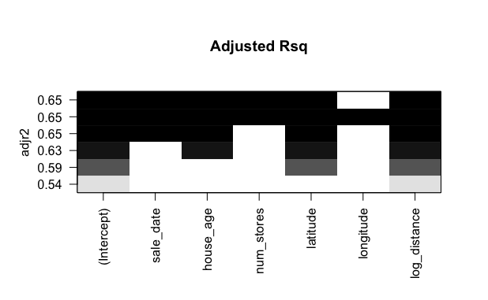

```r
plot(regsubsets_out, scale='adjr2', main='Adjusted Rsq')
```